# Homework_answers

## Question 4

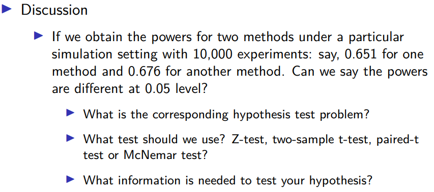

Question 4

## Answer 4

#### 1

The corresponding hypothesis is $H_0:power_1=power_2$.

#### 2

We need to use paired-t test because the two power statistics are derived from the same population.

#### 3

We need to know the degree of freedom.

# HW5-2020-11-03

## Question 1

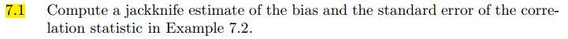

Question 1

## Answer 1

```r
set.seed(12345)
library(bootstrap) #for the law data
data(law, package = "bootstrap")
#data(law82, package = "bootstrap")
rcor <- function(i)
{
  LSAT <- law$LSAT[i] #i is a vector of indices
  GPA <- law$GPA[i]
  return(cor(LSAT,GPA))
}
B <- 200 #number of replicates
n <- nrow(law) #sample size
R <- numeric(n) #storage for replicates
theta.hat <- rcor(1:n)
print(theta.hat)
```

```
## [1] 0.7763745
```

```r
#set up the jackniffe
for (b in 1:n) {
#randomly select the indices
R[b] <- rcor((1:n)[-b])
}
#compute the bias of r
bias.jack <- (n-1)*(mean(R)-theta.hat)
#compute the standard error of r
se.jack <- sqrt((n-1)*mean((R-theta.hat)^2))
round(c(original=theta.hat,bias.jack=bias.jack,
se.jack=se.jack),3)
```

```
##  original bias.jack   se.jack
##     0.776    -0.006     0.143
```

## Question 2

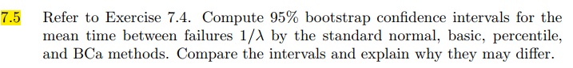

Question 2

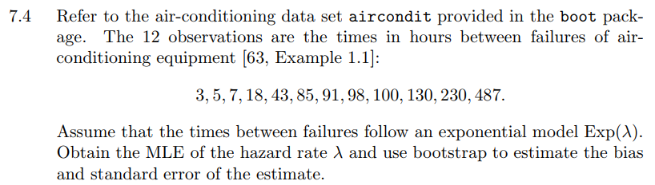

## Answer 2

```r
set.seed(12345)
library(boot)
data(aircondit,package ="boot")
jx<- c(3, 5, 7, 18, 43, 85, 91, 98,100, 130, 230,487)
n<- length(jx)
B<- 1000
mtime <- numeric(B)

#compute the MLE of lamda
f <- function(x,i){
   #g <- function(lamda) n*log(lamda) - lamda*sum(x)
   #1/optimize(g,c(0,1),maximum = TRUE)$maximum
   #return (logL)
  #llamda <- sum(x)/n #1/lamda
  mean(x)
}

#f(jx,1)

for(i in 1:B)
{
 xstar <- sample(jx,replace=TRUE)
 mtime[i] <- mean(xstar)
}

theta <- mean(mtime)
cat('1/lamda =',theta)
```

```
## 1/lamda = 108.0342
```

```r
alpha<-0.05
ci.norm<-ci.basic<-ci.perc<-ci.bca<-matrix(NA,1,2)

#de <- boot(data=jx,statistic=f, R = 999)

#ci <- boot.ci(de,type=c("norm","basic","perc","bca"))

#ci$norm[2:3]
ci.norm[1,]<- c(theta+1*n^(-0.5)*qnorm(alpha/2,0,1),theta-1*n^(-0.5)*qnorm(alpha/2,0,1))

#qnorm((1-alpha)/2,0,1)
#qnorm(alpha/2,0,1)

cat("norm CI is: ",ci.norm)
```

```
## norm CI is:  107.4684 108.6
```

```r
#ci.basic[1,]<-ci$basic[4:5]
#ci.perc[1,]<-ci$percent[4:5]
#ci.bca[1,]<-ci$bca[4:5]

#rbind(ci.norm,ci.basic,ci.perc,ci.bca)
```

## Question 3

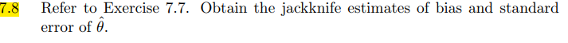

Question 3

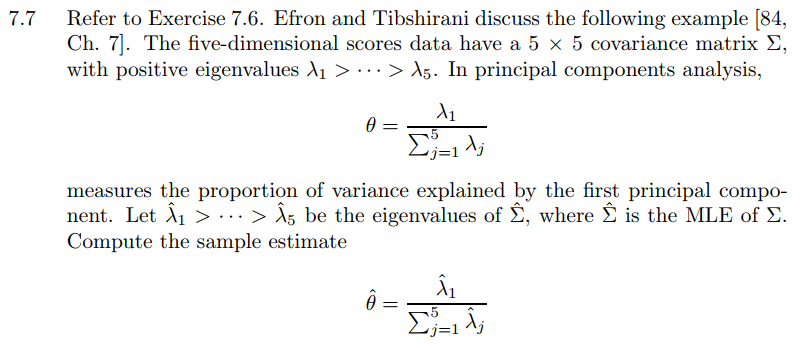

Question 3

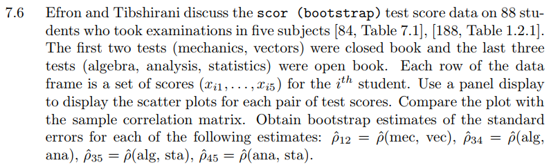

Question 3

## Answer 3

```r
data(scor, package = "bootstrap")
n <- nrow(scor)
m <- ncol(scor)
R<-numeric(n)
theta.hat <- function(x)
{
  s <- cov(x)
  a.e=eigen(s,symmetric=T)$values
  y <- max(a.e)
  z <- sum(a.e)
  theta <- y / z
  return (theta)
}

theta <- theta.hat(scor)
#compute jackknife
for (b in 1:n) {
#randomly select the indices
R[b] <- theta.hat(scor[-b])
}

#compute the bias of r
bias.jack <- (n-1)*(mean(R)-theta)
#compute the standard error of r
se.jack <- sqrt((n-1)*mean((R-theta)^2))

round(c(original=theta,bias.jack=bias.jack,
se.jack=se.jack),3)
```

```
##  original bias.jack   se.jack
##     0.619     0.151     0.090
```

## Question 4

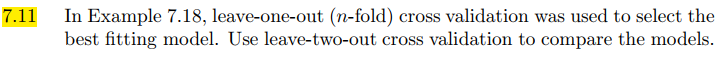

Question 4

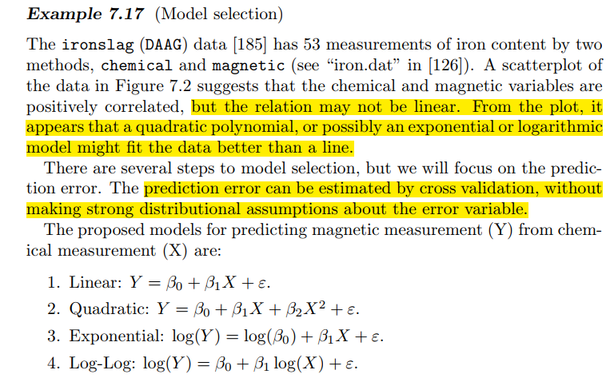

Question 4

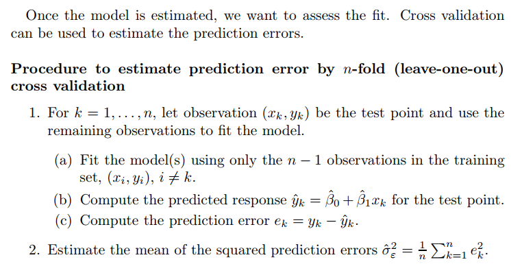

Question 4

## Answer 4

```r
library(DAAG)
```

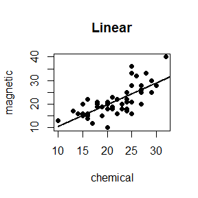

```r
attach(ironslag)
a <- seq(10, 40, .1) #sequence for plotting fits
#fitting four models
L1 <- lm(magnetic ~ chemical) #Fitting Linear Models
plot(chemical, magnetic, main="Linear", pch=16)
yhat1 <- L1$coef[1] + L1$coef[2] * a
lines(a, yhat1, lwd=2)
```

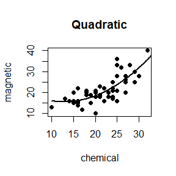

```r
L2 <- lm(magnetic ~ chemical + I(chemical^2))
plot(chemical, magnetic, main="Quadratic", pch=16)
yhat2 <- L2$coef[1] + L2$coef[2] * a + L2$coef[3] * a^2
lines(a, yhat2, lwd=2)
```

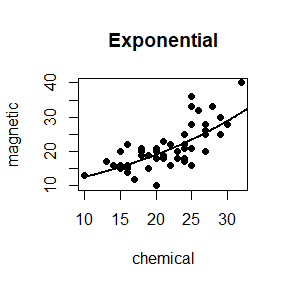

```r
L3 <- lm(log(magnetic) ~ chemical)
plot(chemical, magnetic, main="Exponential", pch=16)
logyhat3 <- L3$coef[1] + L3$coef[2] * a
yhat3 <- exp(logyhat3)
lines(a, yhat3, lwd=2)
```

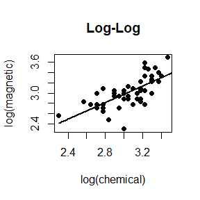

```r
L4 <- lm(log(magnetic) ~ log(chemical))
plot(log(chemical), log(magnetic), main="Log-Log", pch=16)
logyhat4 <- L4$coef[1] + L4$coef[2] * log(a)
lines(log(a), logyhat4, lwd=2)
```

```r
#leave-one-out cross validation
n <- length(magnetic) #in DAAG ironslag
e1 <- e2 <- e3 <- e4 <- numeric(n)
# for n-fold cross validation
# fit models on leave-one-out samples
for (k in 1:n) {
y <- magnetic[-k]
x <- chemical[-k]
J1 <- lm(y ~ x)
yhat1 <- J1$coef[1] + J1$coef[2] * chemical[k]
e1[k] <- magnetic[k] - yhat1

J2 <- lm(y ~ x + I(x^2))
yhat2 <- J2$coef[1] + J2$coef[2] * chemical[k] +
J2$coef[3] * chemical[k]^2
e2[k] <- magnetic[k] - yhat2

J3 <- lm(log(y) ~ x)
logyhat3 <- J3$coef[1] + J3$coef[2] * chemical[k]
yhat3 <- exp(logyhat3)
e3[k] <- magnetic[k] - yhat3

J4 <- lm(log(y) ~ log(x))
logyhat4 <- J4$coef[1] + J4$coef[2] * log(chemical[k])
yhat4 <- exp(logyhat4)
e4[k] <- magnetic[k] - yhat4
}

c(mean(e1^2), mean(e2^2), mean(e3^2), mean(e4^2))
```

```
## [1] 19.55644 17.85248 18.44188 20.45424
```

```r
#leave-two-out cross validation
er1 <- er2 <- er3 <- er4 <- matrix(0,n,n)
for (k in 1:n) {
y <- magnetic[-k]
x <- chemical[-k]
  for (g in 1:(n-1))
{
    yg <- y[-g]
    xg <- x[-g]

    G1 <- lm(yg ~ xg)
    yhat11 <- G1$coef[1] + G1$coef[2] * chemical[k]
    yhat12 <- G1$coef[1] + G1$coef[2] * x[g]
    er1[k,g] <- (magnetic[k] - yhat11+y[g] - yhat12)/2


    G2 <- lm(yg ~ xg + I(xg^2))
    yhat21 <- G2$coef[1] + G2$coef[2] * chemical[k] +
    G2$coef[3] * chemical[k]^2
    yhat22 <- G2$coef[1] + G2$coef[2] * x[g] +
    G2$coef[3] * x[g]^2
    er2[k,g] <- (magnetic[k] - yhat21+y[g] - yhat22)/2

    G3 <- lm(log(yg) ~ xg)
    logyhat31 <- G3$coef[1] + G3$coef[2] * chemical[k]
    yhat31 <- exp(logyhat31)
    logyhat32 <- G3$coef[1] + G3$coef[2] * x[g]
    yhat32 <- exp(logyhat32)
    er3[k,g] <- (magnetic[k] - yhat31+y[g]- yhat32)/2

    G4 <- lm(log(yg) ~ log(xg))
    logyhat41 <- G4$coef[1] + G4$coef[2] * log(chemical[k])
    yhat41 <- exp(logyhat41)
    logyhat42 <- G4$coef[1] + G4$coef[2] * log(x[g])
    yhat42 <- exp(logyhat42)
    er4[k,g] <- (magnetic[k] - yhat41+y[g]- yhat42)/2
  }

}

cat("The one-leave-out cross validation result is: ",c(mean(e1^2), mean(e2^2), mean(e3^2), mean(e4^2)))
```

```
## The one-leave-out cross validation result is:  19.55644 17.85248 18.44188 20.45424
```

```r
cat("The two-leave-out cross validation result is: ",c(mean(er1^2), mean(er2^2), mean(er3^2), mean(er4^2)))
```

```
## The two-leave-out cross validation result is:  9.787158 8.929717 9.314818 10.33882
```

It demonstrates that Model 2, the quadratic model, still be the best fit for the data.

# HW6-2020-11-10

## Question 1

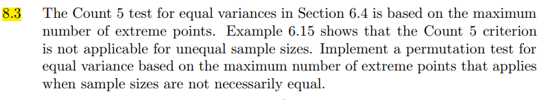

Question 1

## Answer 1

```r
library(RANN)
library(boot)
library(energy)
set.seed(12345)

n1 <- 20
n2 <- 30
mu1 <- mu2 <- 0
sigma1 <- sigma2 <- 1
m <- 10000
alphahat <- mean(replicate(m, expr={
x <- rnorm(n1, mu1, sigma1)
y <- rnorm(n2, mu2, sigma2)
x <- x - mean(x) #centered by sample mean
y <- y - mean(y)
t.test(x,y)$p.value #count5test(x, y)#bd.test(x, y)
}))
cat("t test: ",alphahat)
```

```
## t test:  1
```

```r
#NN test
x <- rnorm(n1, mu1, sigma1)
y <- rnorm(n2, mu2, sigma2)
z <- c(x,y)
Tn <- function(z, ix, k) {
n <- n1 + n2
if(is.vector(z)) z <- data.frame(z,0);
z <- z[ix, ];
NN <- nn2(data=z, k=k+1) # what's the first column?
block1 <- NN$nn.idx[1:n1,-1]
block2 <- NN$nn.idx[(n1+1):n,-1]
i1 <- sum(block1 < n1 + .5);
i2 <- sum(block2 > n1+.5)
(i1 + i2) / (k * n)
}
boot.obj <- boot(data = z, statistic = Tn, R = 999,
sim = "permutation", k=3)
ts <- c(boot.obj$t0,boot.obj$t)
p.value <- mean(ts>=ts[1])
cat("NN test: ",p.value)
```

```
## NN test:  0.279
```

```r
#energy
x <- rnorm(n1, mu1, sigma1)
y <- rnorm(n2, mu2, sigma2)
z <- c(x, y)
N <- c(length(x), length(y))
cat("Energy test: ", eqdist.etest(z, sizes=N, R=m)$p.value)
```

```
## Energy test:  0.5559444
```

## Question 2

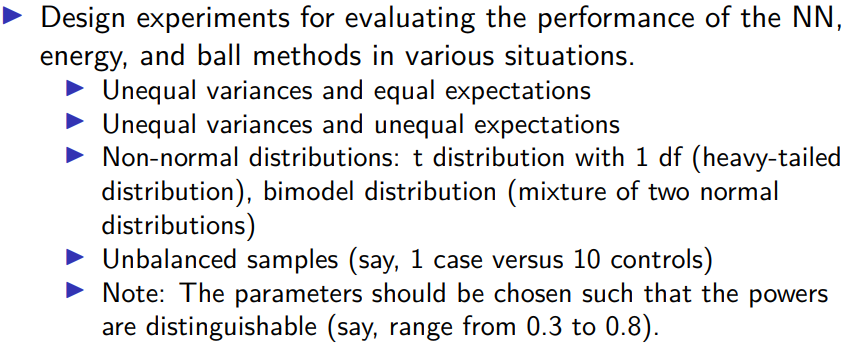

Question 2

```r
#Unequal variances and equal expectations

set.seed(12345)
library(Ball)
library(boot)
library(energy)
library(RANN)
n1 <- 50
n2 <- 50
mu1 <- mu2 <- 0
sigma1 <- 1.4
sigma2 <- 1
m <- 1000
alpha <- 0.05
B <- 100
pvalue <- matrix(0,3,B)
power <- numeric(3)

Tn <- function(z, ix, k) {
n <- n1 + n2
if(is.vector(z)) z <- data.frame(z,0)
z <- z[ix, ]
NN <- nn2(data=z, k=k+1) # what's the first column?
block1 <- NN$nn.idx[1:n1,-1]
block2 <- NN$nn.idx[(n1+1):n,-1]
i1 <- sum(block1 < n1 + .5)
i2 <- sum(block2 > n1+.5)
(i1 + i2) / (k * n)
}

for(i in 1:B)
{
  x <- rnorm(n1, mu1, sigma1)
  y <- rnorm(n2, mu2, sigma2)
  z <- c(x, y)
  boot.obj <- boot(data = z, statistic = Tn, R = m,
  sim = "permutation", k=3)
  ts <- c(boot.obj$t0,boot.obj$t)
  pvalue[1,i] <- mean(ts >= ts[1])
  boot.obs <- eqdist.etest(z, sizes=c(n1,n2), R=m)
  pvalue[2,i] <- boot.obs$p.value
  pvalue[3,i] = bd.test(x = x, y = y, R=m)$p.value
  #bd.test(x = x, y = y, R=m)
}
power1 <- mean(pvalue[1,] <= alpha)
power2 <- mean(pvalue[2,] <= alpha)
power3 <- mean(pvalue[3,] <= alpha)
cat("NN power is: ", power1)
```

```
## NN power is:  0.99
```

```r
cat("Energy power is: ", power2)
```

```
## Energy power is:  0.99
```

```r
cat("Ball power is: ", power3)
```

```
## Ball power is:  0.99
```

```r
#Unequal variances and unequal expectations

set.seed(12345)
library(Ball)
library(boot)
library(energy)
library(RANN)
n1 <- 50
n2 <- 50
mu1 <- 0
mu2 <- 0.2
sigma1 <- 1.3
sigma2 <- 1
m <- 1000
alpha <- 0.05
B <- 100
pvalue <- matrix(0,3,B)
power <- numeric(3)

Tn <- function(z, ix, k) {
n <- n1 + n2
if(is.vector(z)) z <- data.frame(z,0)
z <- z[ix, ]
NN <- nn2(data=z, k=k+1) # what's the first column?
block1 <- NN$nn.idx[1:n1,-1]
block2 <- NN$nn.idx[(n1+1):n,-1]
i1 <- sum(block1 < n1 + .5)
i2 <- sum(block2 > n1+.5)
(i1 + i2) / (k * n)
}

for(i in 1:B)
{
  x <- rnorm(n1, mu1, sigma1)
  y <- rnorm(n2, mu2, sigma2)
  z <- c(x, y)
  boot.obj <- boot(data = z, statistic = Tn, R = m,
  sim = "permutation", k=3)
  ts <- c(boot.obj$t0,boot.obj$t)
  pvalue[1,i] <- mean(ts >= ts[1])
  boot.obs <- eqdist.etest(z, sizes=c(n1,n2), R=m)
  pvalue[2,i] <- boot.obs$p.value
  pvalue[3,i] = bd.test(x = x, y = y, R=m)$p.value
  #bd.test(x = x, y = y, R=m)
}
power1 <- mean(pvalue[1,] <= alpha)
power2 <- mean(pvalue[2,] <= alpha)
power3 <- mean(pvalue[3,] <= alpha)
cat("NN power is: ", power1)
```

```
## NN power is:  0.99
```

```r
cat("Energy power is: ", power2)
```

```
## Energy power is:  0.99
```

```r
cat("Ball power is: ", power3)
```

```
## Ball power is:  0.99
```

```r
#Unnormal distributions

set.seed(12345)
library(Ball)
library(boot)
library(energy)
library(RANN)
n1 <- 100
n2 <- 100
df <- 1
m <- 1000
alpha <- 0.05
B <- 100
pvalue <- matrix(0,3,B)
power <- numeric(3)
mu1 <- 0
mu2 <- 0.2
sigma1 <- 1.3
sigma2 <- 1

Tn <- function(z, ix, k) {
n <- n1 + n2
if(is.vector(z)) z <- data.frame(z,0)
z <- z[ix, ]
NN <- nn2(data=z, k=k+1) # what's the first column?
block1 <- NN$nn.idx[1:n1,-1]
block2 <- NN$nn.idx[(n1+1):n,-1]
i1 <- sum(block1 < n1 + .5)
i2 <- sum(block2 > n1+.5)
(i1 + i2) / (k * n)
}

for(i in 1:B)
{
  x <- rt(n1, df)
  y <- c(rnorm(n2/2, mu1, sigma1),rnorm(n2/2, mu2, sigma2))
  z <- c(x, y)
  boot.obj <- boot(data = z, statistic = Tn, R = m,
  sim = "permutation", k=3)
  ts <- c(boot.obj$t0,boot.obj$t)
  pvalue[1,i] <- mean(ts >= ts[1])
  boot.obs <- eqdist.etest(z, sizes=c(n1,n2), R=m)
  pvalue[2,i] <- boot.obs$p.value
  pvalue[3,i] = bd.test(x = x, y = y, R=m)$p.value

}
power1 <- mean(pvalue[1,] <= alpha)
power2 <- mean(pvalue[2,] <= alpha)
power3 <- mean(pvalue[3,] <= alpha)
cat("NN power is: ", power1)
```

```
## NN power is:  1
```

```r
cat("Energy power is: ", power2)
```

```
## Energy power is:  1
```

```r
cat("Ball power is: ", power3)
```

```
## Ball power is:  1
```

```r
#Unbalanced samples

set.seed(12345)
library(Ball)
library(boot)
library(energy)
library(RANN)
n1 <- 100
n2 <- 10
mu1 <- mu2 <- 0
sigma1 <- 1
sigma2 <- 1
m <- 1000
alpha <- 0.05
B <- 1000
pvalue <- matrix(0,3,B)
power <- numeric(3)

Tn <- function(z, ix, k) {
n <- n1 + n2
if(is.vector(z)) z <- data.frame(z,0)
z <- z[ix, ]
NN <- nn2(data=z, k=k+1) # what's the first column?
block1 <- NN$nn.idx[1:n1,-1]
block2 <- NN$nn.idx[(n1+1):n,-1]
i1 <- sum(block1 < n1 + .5)
i2 <- sum(block2 > n1+.5)
(i1 + i2) / (k * n)
}

for(i in 1:B)
{
  x <- c(rnorm(n2, mu1, sigma1),rt(n1-n2, 1))
  y <- rnorm(n2, mu2, sigma2)
  z <- c(x, y)
  boot.obj <- boot(data = z, statistic = Tn, R = m,
  sim = "permutation", k=3)
  ts <- c(boot.obj$t0,boot.obj$t)
  pvalue[1,i] <- mean(ts >= ts[1])
  boot.obs <- eqdist.etest(z, sizes=c(n1,n2), R=m)
  pvalue[2,i] <- boot.obs$p.value
  pvalue[3,i] = bd.test(x = x, y = y, R=m)$p.value
  #bd.test(x = x, y = y, R=m)
}
power1 <- mean(pvalue[1,] <= alpha)
power2 <- mean(pvalue[2,] <= alpha)
power3 <- mean(pvalue[3,] <= alpha)
cat("NN power is: ", power1)
```

```
## NN power is:  0
```

```r
cat("Energy power is: ", power2)
```

```
## Energy power is:  0
```

```r
cat("Ball power is: ", power3)
```

```
## Ball power is:  0.999
```

# HW7-2020-11-17

## Question 1

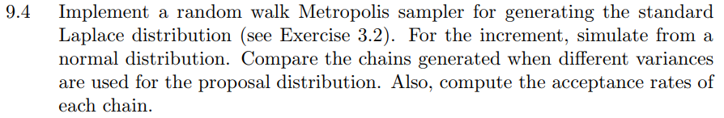

Question 1

## Answer 1

The density function of standard Laplace Distribution is:

$$\begin{equation}
p(x) = \frac{1}{2}{e^{ - \left| x \right|}}
\end{equation}$$

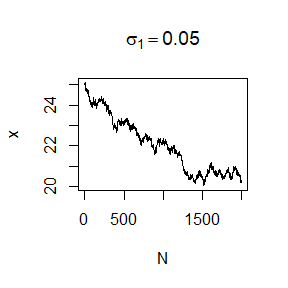

```r
set.seed(12345)
#laplace density
laplace <- function(x) {
return(exp(-abs(x))/2)
}

rw.Metropolis <- function(sigma, x0, N) {
x <- numeric(N)
x[1] <- x0
u <- runif(N)
k <- 0
for (i in 2:N) {
y <- rnorm(1, x[i-1], sigma)
if (u[i] <= (laplace (y) / laplace(x[i-1]))) { x[i] <- y }
 else {
x[i] <- x[i-1]
k <- k + 1
 }
}
return(list(x=x, acceptance_rate=1-k/(N-1)))
}



N <- 2000
sigma <- c(.05, 0.1, 0.5, 2, 4)
x0 <- 25
m <- length(sigma)
#rw <- numeric(m)
#rates <- numeric(m)


rw1 <- rw.Metropolis(sigma[1], x0, N)
rw2 <- rw.Metropolis(sigma[2], x0, N)
rw3 <- rw.Metropolis(sigma[3], x0, N)
rw4 <- rw.Metropolis(sigma[4], x0, N)
rw5 <- rw.Metropolis(sigma[5], x0, N)
rates <- c(rw1$acceptance_rate,rw2$acceptance_rate,rw3$acceptance_rate,rw4$acceptance_rate,rw5$acceptance_rate)

#graph comparison
index <- 1:N
t1 <- expression(sigma[1] == 0.05)
plot(index, rw1$x, type="l", main=t1, xlab='N', ylab="x")
```

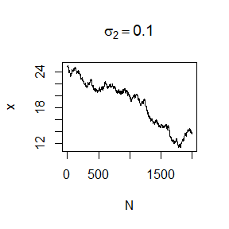

```r
t2 <- expression(sigma[2] == 0.1)
plot(index, rw2$x, type="l", main=t2, xlab='N', ylab="x")
```

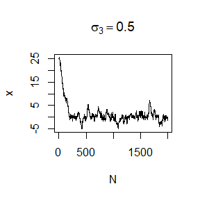

```r
t3 <- expression(sigma[3] == 0.5)
plot(index, rw3$x, type="l", main=t3, xlab='N', ylab="x")
```

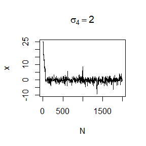

```r
t4 <- expression(sigma[4] == 2)
plot(index, rw4$x, type="l", main=t4, xlab='N', ylab="x")
```

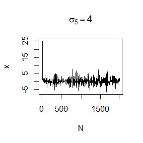

```r
t5 <- expression(sigma[5] == 4)
plot(index, rw5$x, type="l", main=t5, xlab='N', ylab="x")
```

```r
#acceptance_rate
rbind(sigma,rates)
```

```
##            [,1]      [,2]      [,3]      [,4]      [,5]
## sigma 0.0500000 0.1000000 0.5000000 2.0000000 4.0000000
## rates 0.9824912 0.9684842 0.8354177 0.5247624 0.3386693
```

According to the results, the bigger the variance is, the more quickly it converges and the lower the acceptance rate is.

## Question 2

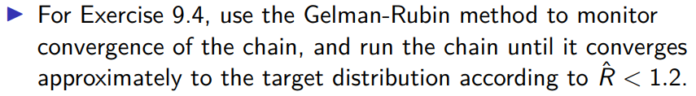

Question 2

## Answer 2

```r
Gelman.Rubin <- function(psi) {
# psi[i,j] is the statistic psi(X[i,1:j])
# for chain in i-th row of X
psi <- as.matrix(psi)
n <- ncol(psi)
k <- nrow(psi)
psi.means <- rowMeans(psi) #row means
B <- n * var(psi.means) #between variance est.
psi.w <- apply(psi, 1, "var") #within variances
W <- mean(psi.w) #within est.
v.hat <- W*(n-1)/n + (B/n) #upper variance est.
r.hat <- v.hat / W #G-R statistic
return(r.hat)
}

#laplace density
laplace <- function(x) {
return(exp(-abs(x))/2)
}

rw.Metropolis <- function(sigma, x0, N) {
x <- numeric(N)
x[1] <- x0
u <- runif(N)
# k <- 0
for (i in 2:N) {
y <- rnorm(1, x[i-1], sigma)
if (u[i] <= (laplace (y) / laplace(x[i-1]))) { x[i] <- y }
 else {
x[i] <- x[i-1]
# k <- k + 1
 }
}
return(x)
}

sigma <- 0.5 #parameter of proposal distribution
k <- 4 #number of chains to generate
n <- 20000 #length of chains
b <- 1000 #burn-in length
#choose overdispersed initial values
x0 <- c(-10, -5, 5, 10)
#generate the chains
X <- matrix(0, nrow=k, ncol=n)
for (i in 1:k)
{
  X[i, ] <- rw.Metropolis(sigma, x0[i],n)
}
#compute diagnostic statistics
psi <- t(apply(X, 1, cumsum))
for (i in 1:nrow(psi))
{
  psi[i,] <- psi[i,] / (1:ncol(psi))
}

cat("R =",Gelman.Rubin(psi))
```

```
## R = 1.184123
```

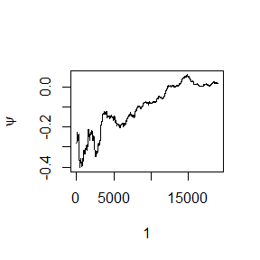

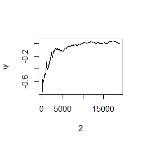

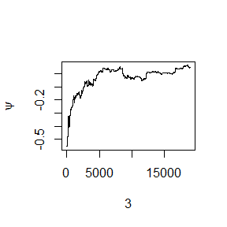

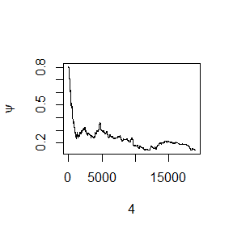

```r
#plot psi for the four chains
#par(mfrow=c(2,2))
for (i in 1:k)
{
  plot(psi[i, (b+1):n], type="l", xlab=i, ylab=bquote(psi))
}
```

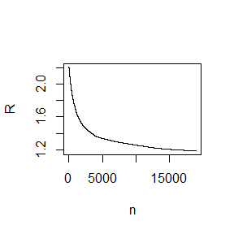

```r
#par(mfrow=c(1,1)) #restore default
#plot the sequence of R-hat statistics
rhat <- rep(0, n)
for (j in (b+1):n)
{
  rhat[j] <- Gelman.Rubin(psi[,1:j])
}
plot(rhat[(b+1):n], type="l", xlab="n", ylab="R")
abline(h=1.1, lty=2)
```

## Question 3

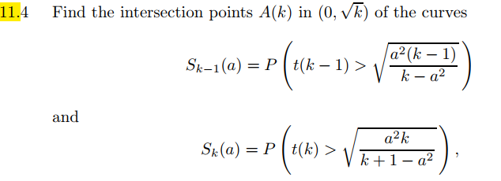

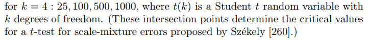

## Answer 3

```r
K <- c(25, 100, 500, 1000)
n <- length(K)
points <- numeric(n)
g <- function(alpha,k){
p1 <- 1-dt(((alpha^2)*(k-1)/(k-(alpha^2)))^0.5, k-1)
p2 <- 1-dt(((alpha^2)*k/(k+1-(alpha^2)))^0.5, k)#lower.tail = FALSE
return(p1-p2)
}
#p1 <- 1-dt(((4^2)*(25-1)/(25-(4^2)))^0.5, 25-1)
#p2 <- 1-dt(((4^2)*25/(25+1-(4^2)))^0.5, 25)

#p1
#p2

points[1]<-uniroot(g,k=25,c(0,25^0.5),tol=1e-9)$root
points[2]<-uniroot(g,k=100,c(0,100^0.5),tol=1e-9)$root
points[3]<-uniroot(g,k=500,round(c(0,500^0.5)),tol=1e-9)$root
points[4]<-uniroot(g,k=1000,c(0,1000^0.5),tol=1e-9)$root

rbind(K,points)
```

```
##        [,1] [,2] [,3]       [,4]
## K        25  100  500 1000.00000
## points    5   10   22   31.62278
```

```r
#floor(500^0.5)
#print(1-dt(((4^2)*25/(25+1-(4^2)))^0.5, 25))
#print(pt(((4^2)*25/(25+1-(4^2)))^0.5, 25))
```

# HW8-2020-11-24

## Question 1

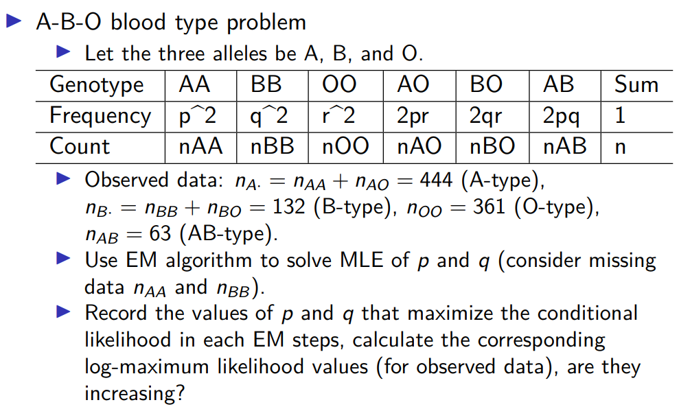

Question 1

## Answer 1

可列出如下方程：
$${p^2} + 2pr = \frac{{{n_{A \cdot }}}}{n}$$
$${q^2} + 2qr = \frac{{{n_{B \cdot }}}}{n}$$

$$2pq = \frac{{{n_{AB}}}}{n}$$

```r
library(stats4)
set.seed(543)
na <- 444
nb <- 132
no <- 361
nab <- 63
n <- na+nb+no+nab
pa <- na/n
pb <- nb/n
r <- (no/n)^0.5

tol <- .Machine$double.eps^0.5
pq <- 0.5*nab/n
N <-10000
fn <- function(p) {
# estimate of p
return((p^2+2*p*r)-(pa))
}
gn <- function(q) {
# estimate of q
return((q^2+2*q*r)-(pb))
}
p <- uniroot(fn,c(0,1),tol=1e-9)$root#runif(1,0,1)
q <- uniroot(gn,c(0,1),tol=1e-9)$root#runif(1,0,1)
logp <- log(p)
logq <- log(q)

rbind(p,q,logp,logq)
```

```
##            [,1]
## p     0.2963852
## q     0.1013068
## logp -1.2160954
## logq -2.2896014
```

## Question 2

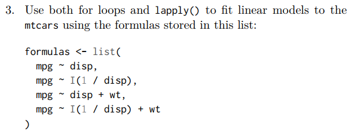

Question 2

## Answer 2

```r
#Loop
data("mtcars")
formulas <- list(
mpg ~ disp,
mpg ~ I(1 / disp),
mpg ~ disp + wt,
mpg ~ I(1 / disp) + wt
)
#formulas[1]
out <- vector("list", length(formulas))

for (i in seq_along(formulas))
{
out[[i]] <- lm(formulas[[i]],data=mtcars)
}
summary(out[[1]])
```

```
##
## Call:
## lm(formula = formulas[[i]], data = mtcars)
##
## Residuals:
##     Min      1Q  Median      3Q     Max
## -4.8922 -2.2022 -0.9631  1.6272  7.2305
##
## Coefficients:
##              Estimate Std. Error t value Pr(>|t|)
## (Intercept) 29.599855   1.229720  24.070  < 2e-16 ***
## disp        -0.041215   0.004712  -8.747 9.38e-10 ***
## ---
## Signif. codes:  0 '***' 0.001 '**' 0.01 '*' 0.05 '.' 0.1 ' ' 1
##
## Residual standard error: 3.251 on 30 degrees of freedom
## Multiple R-squared:  0.7183, Adjusted R-squared:  0.709
## F-statistic: 76.51 on 1 and 30 DF,  p-value: 9.38e-10
```

```r
summary(out[[2]])
```

```
##
## Call:
## lm(formula = formulas[[i]], data = mtcars)
##
## Residuals:
##     Min      1Q  Median      3Q     Max
## -3.7383 -1.8216 -0.0751  1.0487  4.6105
##
## Coefficients:
##              Estimate Std. Error t value Pr(>|t|)
## (Intercept)   10.7520     0.7994   13.45 3.06e-14 ***
## I(1/disp)   1557.6739   114.8935   13.56 2.49e-14 ***
## ---
## Signif. codes:  0 '***' 0.001 '**' 0.01 '*' 0.05 '.' 0.1 ' ' 1
##
## Residual standard error: 2.295 on 30 degrees of freedom
## Multiple R-squared:  0.8597, Adjusted R-squared:  0.855
## F-statistic: 183.8 on 1 and 30 DF,  p-value: 2.494e-14
```

```r
summary(out[[3]])
```

```
##
## Call:
## lm(formula = formulas[[i]], data = mtcars)
##
## Residuals:
##     Min      1Q  Median      3Q     Max
## -3.4087 -2.3243 -0.7683  1.7721  6.3484
##
## Coefficients:
##             Estimate Std. Error t value Pr(>|t|)
## (Intercept) 34.96055    2.16454  16.151 4.91e-16 ***
## disp        -0.01773    0.00919  -1.929  0.06362 .
## wt          -3.35082    1.16413  -2.878  0.00743 **
## ---
## Signif. codes:  0 '***' 0.001 '**' 0.01 '*' 0.05 '.' 0.1 ' ' 1
##
## Residual standard error: 2.917 on 29 degrees of freedom
## Multiple R-squared:  0.7809, Adjusted R-squared:  0.7658
## F-statistic: 51.69 on 2 and 29 DF,  p-value: 2.744e-10
```

```r
summary(out[[4]])
```

```
##
## Call:
## lm(formula = formulas[[i]], data = mtcars)
##
## Residuals:
##     Min      1Q  Median      3Q     Max
## -2.7085 -1.5121 -0.6191  1.5142  4.2314
##
## Coefficients:
##              Estimate Std. Error t value Pr(>|t|)
## (Intercept)   19.0242     3.4520   5.511 6.13e-06 ***
## I(1/disp)   1142.5600   199.8427   5.717 3.47e-06 ***
## wt            -1.7976     0.7327  -2.453   0.0204 *
## ---
## Signif. codes:  0 '***' 0.001 '**' 0.01 '*' 0.05 '.' 0.1 ' ' 1
##
## Residual standard error: 2.124 on 29 degrees of freedom
## Multiple R-squared:  0.8838, Adjusted R-squared:  0.8758
## F-statistic: 110.3 on 2 and 29 DF,  p-value: 2.788e-14
```

```r
#lapply
linearFit <- function(i)
{
  summary(lm(formulas[[i]],data=mtcars))
}
print(lapply(seq_along(formulas),linearFit))
```

```
## [[1]]
##
## Call:
## lm(formula = formulas[[i]], data = mtcars)
##
## Residuals:
##     Min      1Q  Median      3Q     Max
## -4.8922 -2.2022 -0.9631  1.6272  7.2305
##
## Coefficients:
##              Estimate Std. Error t value Pr(>|t|)
## (Intercept) 29.599855   1.229720  24.070  < 2e-16 ***
## disp        -0.041215   0.004712  -8.747 9.38e-10 ***
## ---
## Signif. codes:  0 '***' 0.001 '**' 0.01 '*' 0.05 '.' 0.1 ' ' 1
##
## Residual standard error: 3.251 on 30 degrees of freedom
## Multiple R-squared:  0.7183, Adjusted R-squared:  0.709
## F-statistic: 76.51 on 1 and 30 DF,  p-value: 9.38e-10
##
##
## [[2]]
##
## Call:
## lm(formula = formulas[[i]], data = mtcars)
##
## Residuals:
##     Min      1Q  Median      3Q     Max
## -3.7383 -1.8216 -0.0751  1.0487  4.6105
##
## Coefficients:
##              Estimate Std. Error t value Pr(>|t|)
## (Intercept)   10.7520     0.7994   13.45 3.06e-14 ***
## I(1/disp)   1557.6739   114.8935   13.56 2.49e-14 ***
## ---
## Signif. codes:  0 '***' 0.001 '**' 0.01 '*' 0.05 '.' 0.1 ' ' 1
##
## Residual standard error: 2.295 on 30 degrees of freedom
## Multiple R-squared:  0.8597, Adjusted R-squared:  0.855
## F-statistic: 183.8 on 1 and 30 DF,  p-value: 2.494e-14
```

[output cut: 29 more lines]

```
## Residuals:
##     Min      1Q  Median      3Q     Max
## -2.7085 -1.5121 -0.6191  1.5142  4.2314
##
## Coefficients:
##              Estimate Std. Error t value Pr(>|t|)
## (Intercept)   19.0242     3.4520   5.511 6.13e-06 ***
## I(1/disp)   1142.5600   199.8427   5.717 3.47e-06 ***
## wt            -1.7976     0.7327  -2.453   0.0204 *
## ---
## Signif. codes:  0 '***' 0.001 '**' 0.01 '*' 0.05 '.' 0.1 ' ' 1
##
## Residual standard error: 2.124 on 29 degrees of freedom
## Multiple R-squared:  0.8838, Adjusted R-squared:  0.8758
## F-statistic: 110.3 on 2 and 29 DF,  p-value: 2.788e-14
```

## Question 3

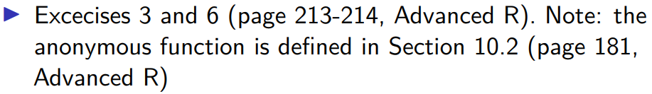

Question 3

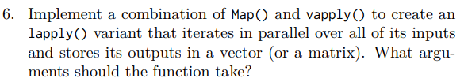

Question 3

## Answer 3

```r
data("mtcars")
formulas <- list(
mpg ~ disp,
mpg ~ I(1 / disp),
mpg ~ disp + wt,
mpg ~ I(1 / disp) + wt
)
lmp <- function(form)
{
  coefficients(lm(form,mtcars))
}

Lm <- function(forms)
{
#vapply(forms,lmp,FUN.VALUE = C(alpha='0',beta='0',sigma='0'))
  Map(lmp,forms)
}

#lmp(formulas[[1]])
Lm(formulas)
```

```
## [[1]]
## (Intercept)        disp
## 29.59985476 -0.04121512
##
## [[2]]
## (Intercept)   I(1/disp)
##    10.75202  1557.67393
##
## [[3]]
## (Intercept)        disp          wt
## 34.96055404 -0.01772474 -3.35082533
##
## [[4]]
## (Intercept)   I(1/disp)          wt
##   19.024206 1142.559975   -1.797649
```

```r
#print(Lm(formulas))
```

The arguments the function takes are formulas.

# HW9-2020-12-02

## Question 1

### Write an Rcpp function for Exercise 9.4 (page 277, Statistical Computing with R).

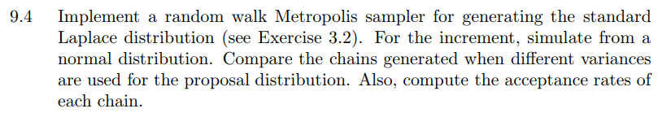

##Answer 1

```r
library(Rcpp) # Attach R package "Rcpp"

#dir_cpp <- 'Rcpp/'
# Can create source file in Rstudio
#sourceCpp(paste0(dir_cpp,"rw_Metropolis.cpp"))
cppFunction('
NumericVector rw_Metropolis(double sigma, int x0, int N) {
NumericVector x(N+1); // the end is k

 x[0] = x0;
 NumericVector u(N);
 u=runif(N,0,1);
 int k = 0;

 for (int i=1; i<N; i++) {
  double x1=x[i-1];
  NumericVector y = rnorm(1, x1, sigma);
  if (u[i] <= exp(-abs(y[0])) / exp(-abs(x1)))
 { x[i] = y[0];
      }
  else {
  x[i] = x[i-1];
  k = k+1;
  }
 }

 x[N]=k;

 return x;
}')

N = 2000
sigma = c(0.05, 0.5, 2, 16)
x0 = 25
rw1 = rw_Metropolis(sigma[1],x0,N)
rw2 = rw_Metropolis(sigma[2],x0,N)
rw3 = rw_Metropolis(sigma[3],x0,N)
rw4 = rw_Metropolis(sigma[4],x0,N)
#number of candidate points rejected
#rw1[1]
Rej = cbind(rw1[N+1], rw2[N+1], rw3[N+1], rw4[N+1])
Acc = round((N-Rej)/N,4)#
rownames(Acc) = "Accept rates"
colnames(Acc) = paste("sigma",sigma)
knitr::kable(Acc)
```

|  | sigma 0.05 | sigma 0.5 | sigma 2 | sigma 16 |
| --- | --- | --- | --- | --- |
| Accept rates | 0.982 | 0.834 | 0.5435 | 0.096 |

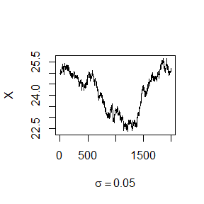

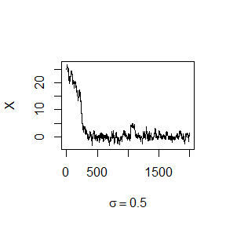

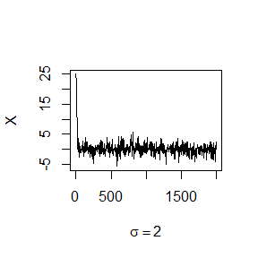

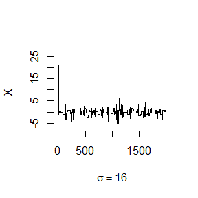

```r
#plot
#par(mfrow=c(2,2))  #display 4 graphs together
    rw = cbind(rw1[1:N], rw2[1:N], rw3[1:N],  rw4[1:N])
    for (j in 1:4) {
        plot(rw[,j], type="l",
             xlab=bquote(sigma == .(round(sigma[j],3))),
             ylab="X", ylim=range(rw[,j]))
    }
```

## Question 2

### Compare the corresponding generated random numbers with those by the R function you wrote before using the function “qqplot”.

## Answer 2

### 以sigma=0.05为例进行对比

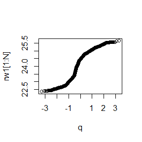

```r
#Rcpp生成
t <- rank(rw1[1:N])/length(rw1[1:N])
q <- qnorm(t)
plot(q, rw1[1:N])
```

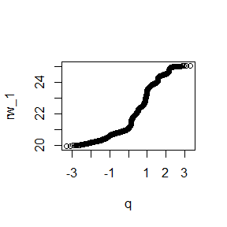

```r
#R生成
lap_f = function(x) exp(-abs(x))

rw.Metropolis = function(sigma, x0, N){
 x = numeric(N)
 x[1] = x0
 u = runif(N)
 k = 0
 for (i in 2:N) {
  y = rnorm(1, x[i-1], sigma)
  if (u[i] <= (lap_f(y) / lap_f(x[i-1]))) x[i] = y
  else {
  x[i] = x[i-1]
  k = k+1
  }
 }
 return(list(x = x, k = k))
}


rw_1 = rw.Metropolis(0.05,25,2000)$x
t <- rank(rw_1)/length(rw_1)
q <- qnorm(t)
plot(q, rw_1)
```

## Question 3

### Campare the computation time of the two functions with the function “microbenchmark”.

## Answer 3

### 以sigma=0.05为例进行对比

```r
library(microbenchmark)
ts <- microbenchmark(rwMetropolisR=rw.Metropolis(0.05,25,2000),
rwMetropolisRCpp=rw_Metropolis(0.05,25,2000))
summary(ts)[,c(1,3,5,6)]
```

```
##               expr       lq   median       uq
## 1    rwMetropolisR 4929.452 5220.151 6425.101
## 2 rwMetropolisRCpp  298.001  305.101  335.251
```

## Question 4

## Answer 4

1)The running time of Rcpp is less than 1/10 of R programs;

2)The QQ curve of the R program is steeper than that of Rcpp.